# TP2 - CART

Ismael Marchesini - Juan Emmanuel Pengue

2023-12-12

```r
library(rpart)
library(rpart.plot)
library(tidyverse)
```

## Sobre los datos:

### Cargamos Datos:

```
##   Q1A Q1I  Q1E Q2A Q2I  Q2E Q3A Q3I   Q3E Q4A Q4I  Q4E Q5A Q5I  Q5E Q6A Q6I
## 1   4  28 3890   4  25 2122   2  16  1944   4   8 2044   4  34 2153   4  33
## 2   4   2 8118   1  36 2890   2  35  4777   3  28 3090   4  10 5078   4  40
## 3   3   7 5784   1  33 4373   4  41  3242   1  13 6470   4  11 3927   3   9
## 4   2  23 5081   3  11 6837   2  37  5521   1  27 4556   3  28 3269   3  26
## 5   2  36 3215   2  13 7731   3   5  4156   4  10 2802   4   2 5628   2   9
## 6   1  18 6116   1  28 3193   2   2 12542   1   8 6150   3  40 6428   1   4
##     Q6E Q7A Q7I  Q7E Q8A Q8I  Q8E Q9A Q9I  Q9E Q10A Q10I Q10E Q11A Q11I Q11E
## 1  2416   4  10 2818   4  13 2259   2  21 5541    1   38 4441    4   31 2451
## 2  2790   3  18 3408   4   1 8342   3  37  916    2   32 1537    2   21 3926
## 3  3704   1  17 4550   3   5 3021   2  32 5864    4   21 3722    2   10 3424
## 4  3231   4   2 7138   2  19 3079   3  31 9650    3   17 4179    2    5 5928
## 5  6522   4  34 2374   4  11 3054   4   7 2975    3   14 3524    2   33 3033
## 6 17001   1  33 2944   3   7 8626   3  14 9639    2   20 6175    1   34 6008
##   Q12A Q12I Q12E Q13A Q13I Q13E Q14A Q14I  Q14E Q15A Q15I Q15E Q16A Q16I Q16E
```

[output cut: 76 more lines]

### Sobre el tratamiento de los datos:

Para nuestro caso de estudio, nos interesa el scoring total en cada escala (Depresión, Ansiedad y Estrés respectivamente). Si bien los autores plantean que no son independientes, sino que están hasta cierto punto correlacionadas, vamos a evaluar el grado de severidad para cada caso. Dado que nuestro dataset contiene el score individual marcado para cada pregunta, calcularemos tres columnas adicionales con el score total de cada estado respectivamente. Asimismo, como en este caso los valores van de 1 a 4, y en el DASS original se puntuan de 0 a 3, vamos a restar 1 a todos los valores.

```r
#Creamos las columnas que nos interesan

columnas_respuesta <- c("Q1A", "Q2A", "Q3A", "Q4A", "Q5A", "Q6A", "Q7A", "Q8A", "Q9A", "Q10A", "Q11A", "Q12A", "Q13A", "Q14A", "Q15A", "Q16A", "Q17A", "Q18A", "Q19A", "Q20A", "Q21A", "Q22A", "Q23A", "Q24A", "Q25A", "Q26A", "Q27A", "Q28A", "Q29A", "Q30A", "Q31A", "Q32A", "Q33A", "Q34A", "Q35A", "Q36A", "Q37A", "Q38A", "Q39A", "Q40A", "Q41A", "Q42A")

# Restar 1 a las 42 columnas al mismo tiempo
df[, columnas_respuesta] <- df[, columnas_respuesta] - 1
```

```r
df$Ansiedad <- rowSums(df[, c("Q2A", "Q4A", "Q7A", "Q9A", "Q15A", "Q19A", "Q20A", "Q23A", "Q25A", "Q28A", "Q30A", "Q36A", "Q40A", "Q41A")])
df$Depresion <- rowSums(df[, c("Q3A", "Q5A", "Q10A", "Q13A", "Q16A", "Q17A", "Q21A", "Q24A", "Q26A", "Q31A", "Q34A", "Q37A", "Q38A", "Q42A")])
df$Stress <- rowSums(df[, c("Q1A", "Q6A", "Q8A", "Q11A", "Q12A", "Q14A", "Q18A", "Q22A", "Q27A", "Q29A", "Q32A", "Q33A", "Q35A", "Q39A")])


#Sabemos ademas que el valor máximo de cada escala es 3 para cada pregunta, y son 14 preguntas, en total 42 puntos es el valor maximo en cada escala.

#Calculamos entonces la proporcion sobre el total maximo

df$Ansiedad_perc <- df$Ansiedad / 42
df$Depresion_perc <- df$Depresion / 42
df$Stress_perc <- df$Stress / 42

head(df[, c("Ansiedad", "Ansiedad_perc", "Depresion", "Depresion_perc", "Stress", "Stress_perc")])
```

```
##   Ansiedad Ansiedad_perc Depresion Depresion_perc Stress Stress_perc
## 1       34     0.8095238        27      0.6428571     40   0.9523810
## 2       17     0.4047619        24      0.5714286     27   0.6428571
## 3       12     0.2857143        39      0.9285714     17   0.4047619
## 4       17     0.4047619        16      0.3809524     16   0.3809524
## 5       40     0.9523810        32      0.7619048     29   0.6904762
## 6        6     0.1428571        13      0.3095238     12   0.2857143
```

También vamos a construir 4 categorias de Severidad para cada Target. Depresion: 0-9 normal, 10-13 leve, 14-20 moderado, 21-42 severo Ansiedad: 0-7 normal, 8-9 leve, 10-14 moderado, 15-42 severo Stress: 0-14 normal, 15-18 leve, 19-25 moderado, 26-42 severo

Información tomada de la hoja de información de DASS: https://static1.squarespace.com/static/5934abbb1b631ba4718d4c2d/t/604d2386f36aae7a6f01fb67/1615668113669/DASS+23+Information+Sheet.2.25.21.docx.pdf

```r
df <- df %>%
  mutate(
    Depresion_cat = case_when(
      between(Depresion, 0, 9) ~ "Normal",
      between(Depresion, 10, 13) ~ "Leve",
      between(Depresion, 14, 20) ~ "Moderado",
      between(Depresion, 21, 42) ~ "Severo",
      TRUE ~ NA_character_
    ),
    Ansiedad_cat = case_when(
      between(Ansiedad, 0, 7) ~ "Normal",
      between(Ansiedad, 8, 9) ~ "Leve",
      between(Ansiedad, 10, 14) ~ "Moderado",
      between(Ansiedad, 15, 42) ~ "Severo",
      TRUE ~ NA_character_
    ),
    Stress_cat = case_when(
      between(Stress, 0, 14) ~ "Normal",
      between(Stress, 15, 18) ~ "Leve",
      between(Stress, 19, 25) ~ "Moderado",
      between(Stress, 26, 42) ~ "Severo",
      TRUE ~ NA_character_
    )
)
```

Además de esto, contamos con la escala de Ten Item Personality Inventory, que contiene 10 preguntas que se responden con números del 1 al 7. En base al manual de dicho inventario, debemos recodificar algunas respuestas de la siguiente manera:

Para los items 2, 4, 6, 8 y 10, codificar a la inversa: 7 como 1, 6 como 2, 5 como 3, etc.

```r
# Columnas a codificar
columnas_a_codificar <- c("TIPI2", "TIPI4", "TIPI6", "TIPI8", "TIPI10")

# Codificación inversa
df <- df %>%
  mutate(across(all_of(columnas_a_codificar), ~if_else(. %in% c(1, 2, 3, 4, 5, 6, 7), recode(., `7` = 1, `6` = 2, `5` = 3, `4` = 4, `3` = 5, `2` = 6, `1` = 7), .)))
```

Ahora vamos a calcular las sumas de cada rasgo de Personalidad: Extroversion, Agreeableness, Conscientiousness, Emotional Stability, Openness, y sus respectivos valores porcentuales (máximo es 7)

```r
df$Extraversion <- (df$TIPI1 + df$TIPI6) / 2
df$Extraversion_perc <- df$Extraversion / 7
df$Agreeableness <- (df$TIPI2 + df$TIPI7) / 2
df$Agreeableness_perc <- df$Agreeableness / 7
df$Conscientiousness <- (df$TIPI3 + df$TIPI8) / 2
df$Conscientiousness_perc <- df$Conscientiousness / 7
df$EmotionalStability <- (df$TIPI4 + df$TIPI9) / 2
df$EmotionalStability_perc <- df$EmotionalStability / 7
df$Openness <- (df$TIPI5 + df$TIPI10) / 2
df$Openness_perc <- df$Openness / 7
head(df[, c("Extraversion", "Extraversion_perc", "Agreeableness", "Agreeableness_perc", "Conscientiousness", "Conscientiousness_perc", "EmotionalStability", "EmotionalStability_perc", "Openness", "Openness_perc")])
```

```
##   Extraversion Extraversion_perc Agreeableness Agreeableness_perc
## 1          1.0         0.1428571           5.0          0.7142857
## 2          5.0         0.7142857           5.0          0.7142857
## 3          2.0         0.2857143           4.0          0.5714286
## 4          2.5         0.3571429           6.5          0.9285714
## 5          2.5         0.3571429           4.0          0.5714286
## 6          1.5         0.2142857           7.0          1.0000000
##   Conscientiousness Conscientiousness_perc EmotionalStability
## 1               5.0              0.7142857                1.0
## 2               2.5              0.3571429                1.0
## 3               2.5              0.3571429                4.5
## 4               7.0              1.0000000                5.0
## 5               2.5              0.3571429                2.5
## 6               6.0              0.8571429                6.5
##   EmotionalStability_perc Openness Openness_perc
## 1               0.1428571      7.0     1.0000000
## 2               0.1428571      4.0     0.5714286
## 3               0.6428571      5.5     0.7857143
## 4               0.7142857      6.5     0.9285714
## 5               0.3571429      5.0     0.7142857
## 6               0.9285714      4.0     0.5714286
```

Ademas vamos a filtrar aquellos valores que en VCL6, VCL9 y VCL12 tengan como respuesta un “1” ya que son preguntas-señuelo que nos indican que la persona no estaba concentrada, o contestó al azar, o no podemos asegurar que haya comprendido correctamente las consignas. Lo mismo haremos en los casos donde todas las preguntas VCL sean 0, ya que también indicaría que esos resultados no son confiables.

```r
library(ggplot2)

# Calculamos la proporción de datos que vamos a eliminar
prop_condicion <- df %>%
  filter(VCL6 == 1 | VCL9 == 1 | VCL12 == 1 | (VCL1 == 0 & VCL2 == 0 & VCL3 == 0 & VCL4 == 0 & VCL5 == 0 & VCL6 == 0 & VCL7 == 0 & VCL8 == 0 & VCL9 == 0 & VCL10 == 0 & VCL11 == 0 & VCL12 == 0)) %>%
  nrow() / nrow(df)




# Filtrar las filas que cumplen la condición y actualizar el dataframe
df_filtrado <- df %>%
  filter(!(VCL6 == 1 | VCL9 == 1 | VCL12 == 1 | (VCL1 == 0 & VCL2 == 0 & VCL3 == 0 & VCL4 == 0 & VCL5 == 0 & VCL6 == 0 & VCL7 == 0 & VCL8 == 0 & VCL9 == 0 & VCL10 == 0 & VCL11 == 0 & VCL12 == 0)))

# Muestra los primeros registros del dataframe filtrado
head(df_filtrado)
```

```
##   Q1A Q1I  Q1E Q2A Q2I  Q2E Q3A Q3I   Q3E Q4A Q4I  Q4E Q5A Q5I  Q5E Q6A Q6I
## 1   3  28 3890   3  25 2122   1  16  1944   3   8 2044   3  34 2153   3  33
## 2   3   2 8118   0  36 2890   1  35  4777   2  28 3090   3  10 5078   3  40
## 3   2   7 5784   0  33 4373   3  41  3242   0  13 6470   3  11 3927   2   9
## 4   1  23 5081   2  11 6837   1  37  5521   0  27 4556   2  28 3269   2  26
## 5   1  36 3215   1  13 7731   2   5  4156   3  10 2802   3   2 5628   1   9
## 6   0  18 6116   0  28 3193   1   2 12542   0   8 6150   2  40 6428   0   4
##     Q6E Q7A Q7I  Q7E Q8A Q8I  Q8E Q9A Q9I  Q9E Q10A Q10I Q10E Q11A Q11I Q11E
## 1  2416   3  10 2818   3  13 2259   1  21 5541    0   38 4441    3   31 2451
## 2  2790   2  18 3408   3   1 8342   2  37  916    1   32 1537    1   21 3926
## 3  3704   0  17 4550   2   5 3021   1  32 5864    3   21 3722    1   10 3424
## 4  3231   3   2 7138   1  19 3079   2  31 9650    2   17 4179    1    5 5928
## 5  6522   3  34 2374   3  11 3054   3   7 2975    2   14 3524    1   33 3033
## 6 17001   0  33 2944   2   7 8626   2  14 9639    1   20 6175    0   34 6008
##   Q12A Q12I Q12E Q13A Q13I Q13E Q14A Q14I  Q14E Q15A Q15I Q15E Q16A Q16I Q16E
```

[output cut: 104 more lines]

Asimismo, quitaremos todos aquellos registros donde todas las respuestas tengan el mismo valor.

```r
filas_con_mismo_valor <- apply(df_filtrado[, grep("^Q\\d+A$", colnames(df_filtrado))], 1, function(x) length(unique(x)) == 1)

# Filtrar el dataframe
df_filtrado <- df_filtrado[!filas_con_mismo_valor, ]

cat("Número de filas después de limpiar:", nrow(df_filtrado), "\n")
```

```
## Número de filas después de limpiar: 32505
```

### Duracion

Estas medidas nos permiten observar que hay datos máximos que llaman la atención. Para asegurar que los datos sean confiables, vamos a filtrar aquellos que sean outliers en tiempo (testelapse, surveyelapse), y también aquellos donde todas las respuestas hayan sido con el mismo puntaje (todas 4, o todas 1, o todas 2, o todas 3, etc)

```r
columnas_duracion <- c("testelapse", "sum_T_elapsed", "surveyelapse")

df_filtrado$sum_T_elapsed <- rowSums(df_filtrado[, grep("^Q\\d+E$", colnames(df_filtrado))])
df_filtrado$sum_T_elapsed <- df_filtrado$sum_T_elapsed / 1000
head(df_filtrado[,columnas_duracion])
```

```
##   testelapse sum_T_elapsed surveyelapse
## 1        167       157.622          166
## 2        193       168.927          186
## 3        271       270.194          122
## 4        261       253.531          336
## 5        164       163.402          157
## 6        349       348.041          213
```

```r
summary(df_filtrado[,columnas_duracion])
```

```
##    testelapse       sum_T_elapsed        surveyelapse
##  Min.   :      14   Min.   :    11.19   Min.   :       1
##  1st Qu.:     167   1st Qu.:   159.69   1st Qu.:     147
##  Median :     216   Median :   204.99   Median :     187
##  Mean   :    3012   Mean   :   317.00   Mean   :    4995
##  3rd Qu.:     299   3rd Qu.:   277.66   3rd Qu.:     249
##  Max.   :20829721   Max.   :151401.02   Max.   :20828454
```

Dado que testelapse y surveyelapse corresponden a el tiempo en segundos que se tardó en responde todo el test, tenemos que considerar que siendo 42 preguntas del test no podemos confiar demasiado en aquellos registros que hayan tardado menos de 1 minuto y más de 40 minutos

```r
df_filtrado <- df_filtrado %>%
  filter(testelapse >= 60, testelapse <= 2400, surveyelapse <= 2400, surveyelapse >=60)
```

Habiendo limpiado los absurdos, vamos a verificar los outliers.

```r
iqr_testelapse <- IQR(df_filtrado$testelapse)
iqr_surveyelapse <- IQR(df_filtrado$surveyelapse)

# Definir los límites para identificar outliers
limite_superior_testelapse <- quantile(df_filtrado$testelapse)[4] + 1.5 * iqr_testelapse
limite_inferior_testelapse <- quantile(df_filtrado$testelapse)[2] - 1.5 * iqr_testelapse

limite_superior_surveyelapse <- quantile(df_filtrado$surveyelapse)[4] + 1.5 * iqr_surveyelapse
limite_inferior_surveyelapse <- quantile(df_filtrado$surveyelapse)[2] - 1.5 * iqr_surveyelapse

# Identificar outliers en testelapse y surveyelapse
outliers_testelapse <- df_filtrado$testelapse > limite_superior_testelapse | df_filtrado$testelapse < limite_inferior_testelapse
outliers_surveyelapse <- df_filtrado$surveyelapse > limite_superior_surveyelapse | df_filtrado$surveyelapse < limite_inferior_surveyelapse

# Contar y mostrar los outliers
cat("Número de outliers en testelapse:", sum(outliers_testelapse), "\n")
```

```
## Número de outliers en testelapse: 2580
```

```r
cat("Número de outliers en surveyelapse:", sum(outliers_surveyelapse), "\n")
```

```
## Número de outliers en surveyelapse: 2191
```

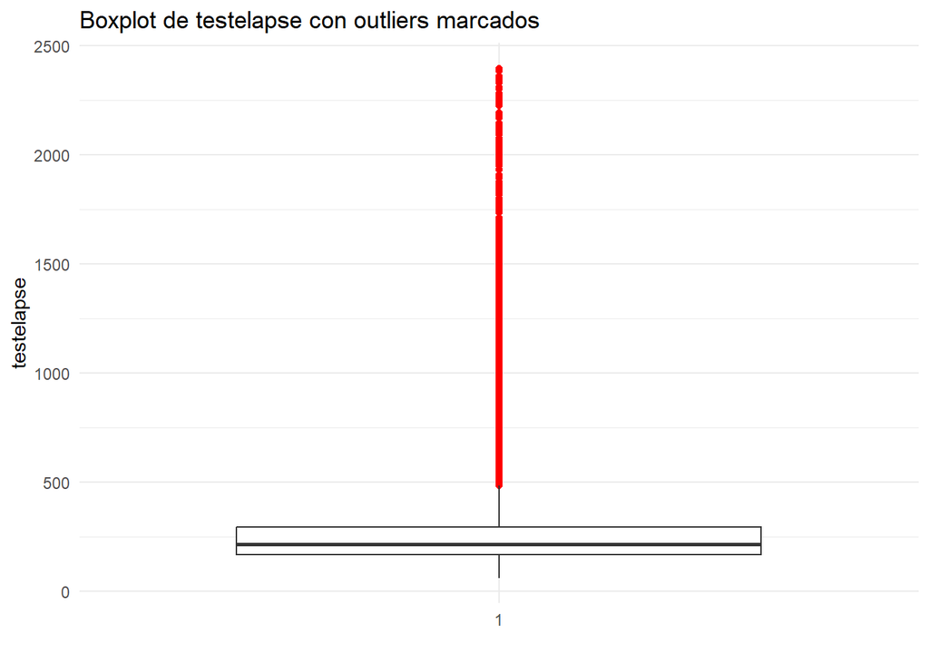

```r
# Crear un boxplot para testelapse con outliers marcados
ggplot(df_filtrado, aes(x = factor(1), y = testelapse)) +
  geom_boxplot(outlier.shape = 16, outlier.colour = "red") +
  labs(title = "Boxplot de testelapse con outliers marcados",
       x = "",
       y = "testelapse") +
  theme_minimal()
```

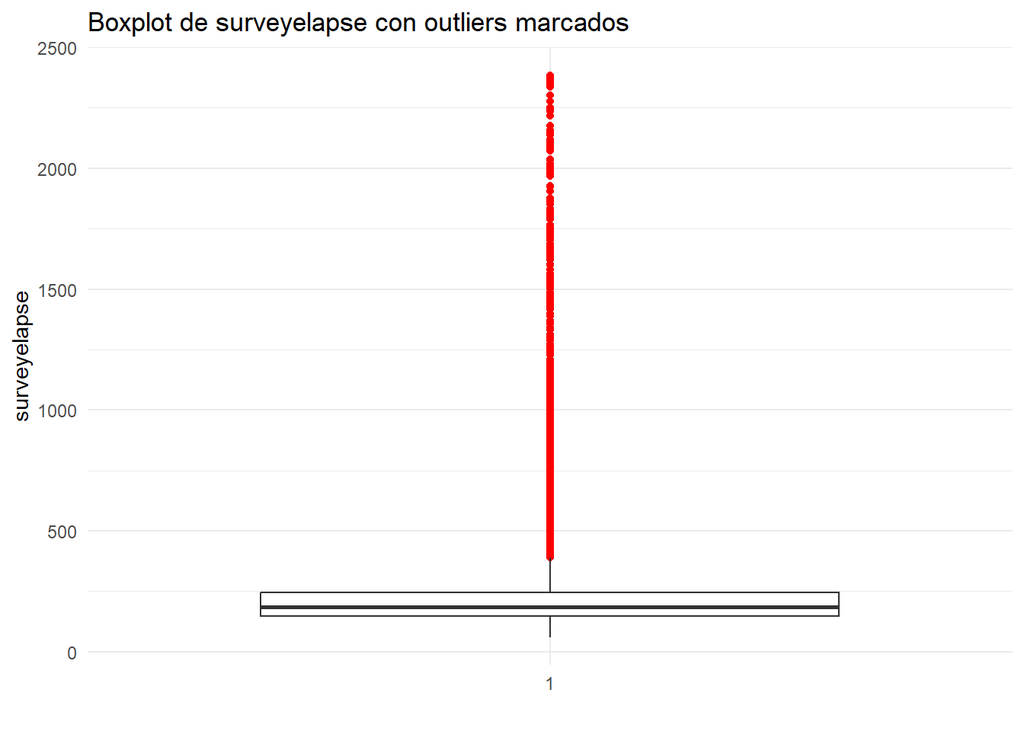

```r
# Crear un boxplot para surveyelapse con outliers marcados
ggplot(df_filtrado, aes(x = factor(1), y = surveyelapse)) +
  geom_boxplot(outlier.shape = 16, outlier.colour = "red") +
  labs(title = "Boxplot de surveyelapse con outliers marcados",
       x = "",
       y = "surveyelapse") +
  theme_minimal()
```

Ahora procedemos a filtrar los outliers y observar los boxplots luego de quitar outliers.

```r
df_filtrado <- df_filtrado %>%
  filter(testelapse >= limite_inferior_testelapse, testelapse <= limite_superior_testelapse,
         surveyelapse >= limite_inferior_surveyelapse, surveyelapse <= limite_superior_surveyelapse)

# Verificar el nuevo tamaño del dataframe después de la eliminación de outliers
cat("Número de filas después de eliminar outliers:", nrow(df_filtrado), "\n")
```

```
## Número de filas después de eliminar outliers: 27539
```

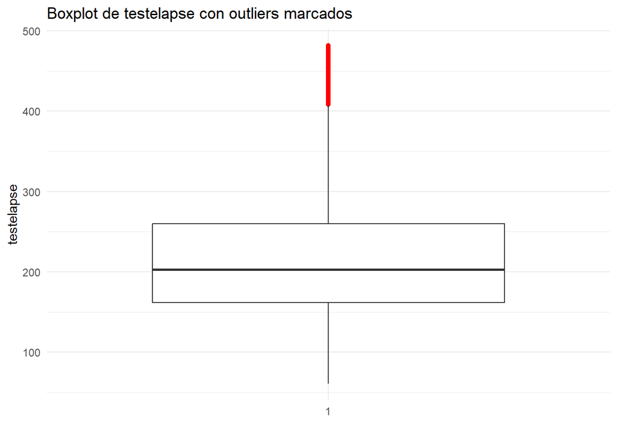

```r
# Crear un boxplot para testelapse con outliers marcados
ggplot(df_filtrado, aes(x = factor(1), y = testelapse)) +
  geom_boxplot(outlier.shape = 16, outlier.colour = "red") +
  labs(title = "Boxplot de testelapse con outliers marcados",
       x = "",
       y = "testelapse") +
  theme_minimal()
```

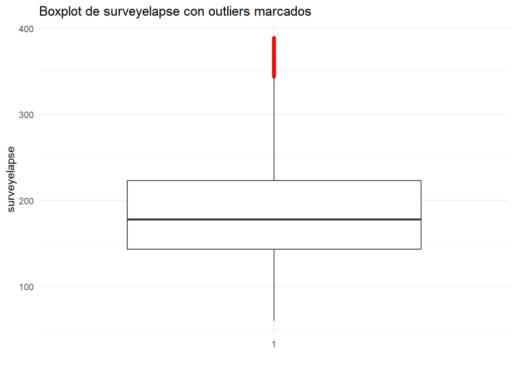

```r
# Crear un boxplot para surveyelapse con outliers marcados
ggplot(df_filtrado, aes(x = factor(1), y = surveyelapse)) +
  geom_boxplot(outlier.shape = 16, outlier.colour = "red") +
  labs(title = "Boxplot de surveyelapse con outliers marcados",
       x = "",
       y = "surveyelapse") +
  theme_minimal()
```

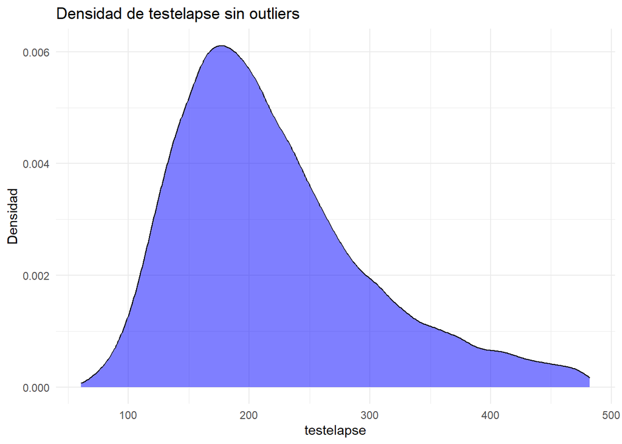

```r
ggplot(df_filtrado, aes(x = testelapse)) +
  geom_density(fill = "blue", alpha = 0.5) +
  labs(title = "Densidad de testelapse sin outliers",
       x = "testelapse",
       y = "Densidad") +
  theme_minimal()
```

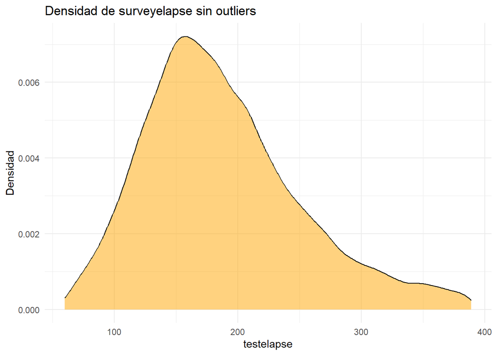

```r
ggplot(df_filtrado, aes(x = surveyelapse)) +
  geom_density(fill = "orange", alpha = 0.5) +
  labs(title = "Densidad de surveyelapse sin outliers",
       x = "testelapse",
       y = "Densidad") +
  theme_minimal()
```

## EDA - Analisis Exploratorio

### Variables Target

Verificaremos las variables que seran las target: Depresion, Ansiedad y Stress

Se puede observar que el Stress tiene una distribución que se asemeja un poco a una normal a primera vista, mientras que la Depresión tiene una distribución considerablemente más uniforme, y la Ansiedad se asemeja un poco a una Chi-cuadrado.

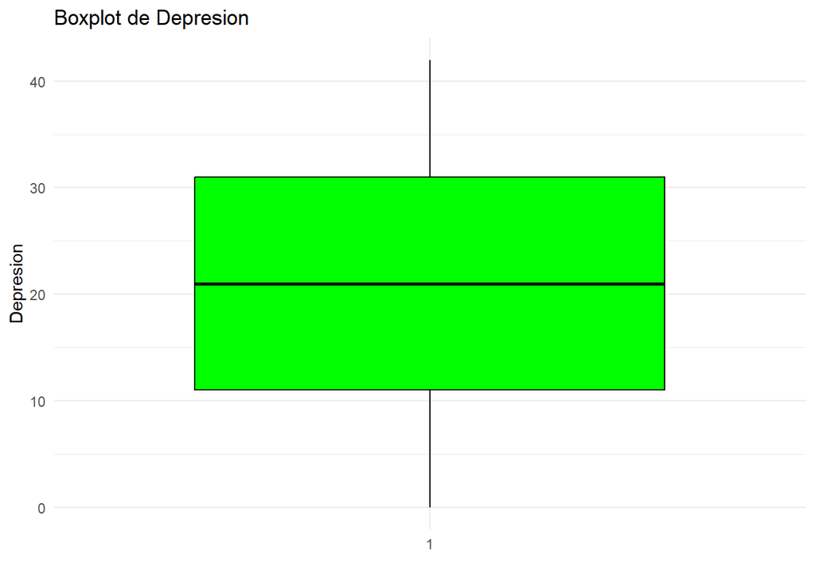

```r
# Definir colores para cada variable
color_depresion <- "green"
color_ansiedad <- "orange"
color_stress <- "purple"
colores_depresion <- c("green", "yellow", "orange", "red")

ggplot(df_filtrado, aes(x = factor(1), y = Depresion)) +
  geom_boxplot(fill = color_depresion, color = "black") +
  labs(title = "Boxplot de Depresion",
       x = "",
       y = "Depresion") +
  theme_minimal()
```

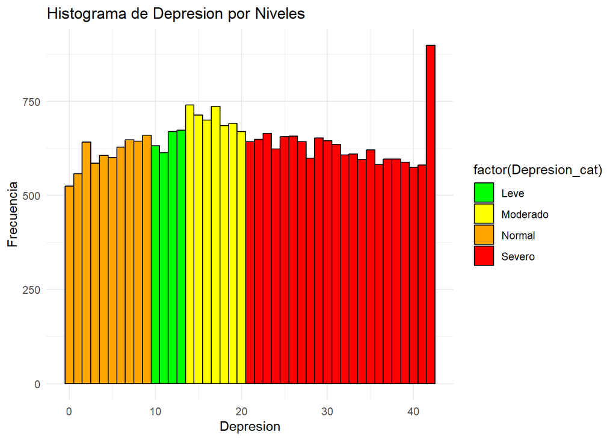

```r
# Crear el gráfico utilizando ggplot2 con un margen más amplio en el eje x
ggplot(df_filtrado, aes(x = Depresion, fill = factor(Depresion_cat))) +
  geom_histogram(color = "black", binwidth = 1, position = "identity") +

  # Personalizar colores
  scale_fill_manual(values = colores_depresion) +

  labs(title = "Histograma de Depresion por Niveles",
       x = "Depresion",
       y = "Frecuencia") +

  theme_minimal()
```

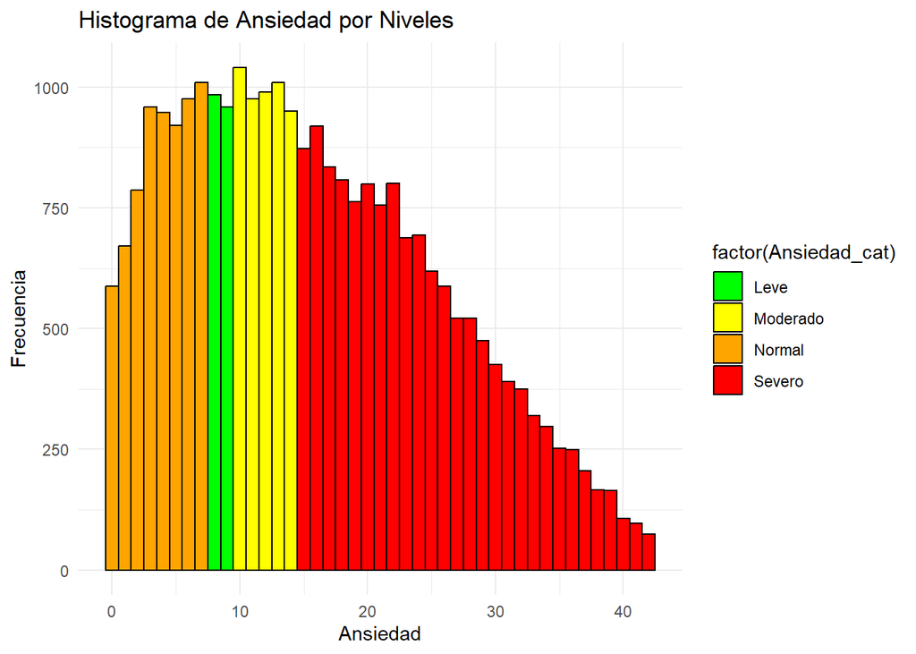

```r
ggplot(df_filtrado, aes(x = Ansiedad, fill = factor(Ansiedad_cat))) +
  geom_histogram(color = "black", binwidth = 1, position = "identity") +

  # Personalizar colores
  scale_fill_manual(values = colores_depresion) +

  labs(title = "Histograma de Ansiedad por Niveles",
       x = "Ansiedad",
       y = "Frecuencia") +

  theme_minimal()
```

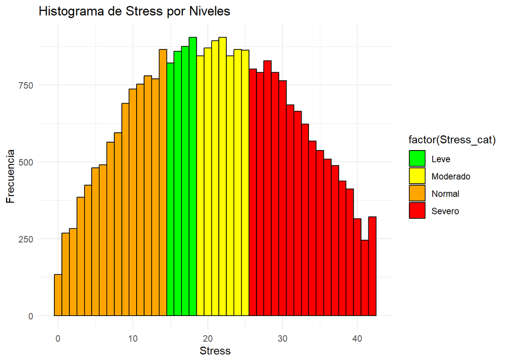

```r
ggplot(df_filtrado, aes(x = Stress, fill = factor(Stress_cat))) +
  geom_histogram(color = "black", binwidth = 1, position = "identity") +

  # Personalizar colores
  scale_fill_manual(values = colores_depresion) +

  labs(title = "Histograma de Stress por Niveles",
       x = "Stress",
       y = "Frecuencia") +

  theme_minimal()
```

```r
columnas_personales <- c("education", "urban", "gender", "engnat", "age", "hand", "religion", "orientation", "race", "voted", "married", "familysize")

columnas_duracion <- c("testelapse", "surveyelapse")

columnas_interesantes <- c("Depresion","Ansiedad","Stress",  "Extraversion", "Agreeableness",  "Conscientiousness", "EmotionalStability", "Openness")

cat("Summary interesantes: ")
```

```
## Summary interesantes:
```

```r
summary(df_filtrado[, columnas_interesantes])
```

```
##    Depresion        Ansiedad         Stress       Extraversion
##  Min.   : 0.00   Min.   : 0.00   Min.   : 0.00   Min.   :0.000
##  1st Qu.:11.00   1st Qu.: 8.00   1st Qu.:13.00   1st Qu.:2.000
##  Median :21.00   Median :15.00   Median :21.00   Median :3.500
##  Mean   :21.07   Mean   :15.81   Mean   :21.05   Mean   :3.401
##  3rd Qu.:31.00   3rd Qu.:23.00   3rd Qu.:29.00   3rd Qu.:4.500
##  Max.   :42.00   Max.   :42.00   Max.   :42.00   Max.   :7.000
##  Agreeableness   Conscientiousness EmotionalStability    Openness
##  Min.   :0.000   Min.   :0.000     Min.   :0.000      Min.   :0.000
##  1st Qu.:4.000   1st Qu.:3.000     1st Qu.:2.000      1st Qu.:3.500
##  Median :4.500   Median :4.000     Median :3.000      Median :4.500
##  Mean   :4.501   Mean   :4.168     Mean   :3.178      Mean   :4.531
##  3rd Qu.:5.500   3rd Qu.:5.500     3rd Qu.:4.000      3rd Qu.:5.500
##  Max.   :7.000   Max.   :7.000     Max.   :7.000      Max.   :7.000
```

```r
cat("Summary duracion: ")
```

```
## Summary duracion:
```

```r
summary(df_filtrado[,columnas_duracion])
```

```
##    testelapse     surveyelapse
##  Min.   : 61.0   Min.   : 60.0
##  1st Qu.:162.0   1st Qu.:143.0
##  Median :203.0   Median :178.0
##  Mean   :219.3   Mean   :187.8
##  3rd Qu.:260.0   3rd Qu.:223.0
##  Max.   :482.0   Max.   :389.0
```

```r
cat("Summary personales: ")
```

```
## Summary personales:
```

```r
summary(df_filtrado[,columnas_personales])
```

```
##    education         urban           gender          engnat
##  Min.   :0.000   Min.   :0.000   Min.   :0.000   Min.   :0.000
##  1st Qu.:2.000   1st Qu.:2.000   1st Qu.:2.000   1st Qu.:1.000
##  Median :3.000   Median :2.000   Median :2.000   Median :2.000
##  Mean   :2.517   Mean   :2.227   Mean   :1.789   Mean   :1.642
##  3rd Qu.:3.000   3rd Qu.:3.000   3rd Qu.:2.000   3rd Qu.:2.000
##  Max.   :4.000   Max.   :3.000   Max.   :3.000   Max.   :2.000
##       age               hand          religion       orientation
##  Min.   :  13.00   Min.   :0.000   Min.   : 0.000   Min.   :0.000
##  1st Qu.:  18.00   1st Qu.:1.000   1st Qu.: 4.000   1st Qu.:1.000
##  Median :  21.00   Median :1.000   Median :10.000   Median :1.000
##  Mean   :  23.62   Mean   :1.129   Mean   : 7.533   Mean   :1.646
##  3rd Qu.:  25.00   3rd Qu.:1.000   3rd Qu.:10.000   3rd Qu.:2.000
##  Max.   :1998.00   Max.   :3.000   Max.   :12.000   Max.   :5.000
##       race           voted          married        familysize
##  Min.   :10.00   Min.   :0.000   Min.   :0.000   Min.   : 0.000
##  1st Qu.:10.00   1st Qu.:1.000   1st Qu.:1.000   1st Qu.: 2.000
##  Median :10.00   Median :2.000   Median :1.000   Median : 3.000
##  Mean   :31.21   Mean   :1.711   Mean   :1.153   Mean   : 3.482
##  3rd Qu.:60.00   3rd Qu.:2.000   3rd Qu.:1.000   3rd Qu.: 4.000
##  Max.   :70.00   Max.   :2.000   Max.   :3.000   Max.   :99.000
```

### Variables de interés predictivo

Vamos a analizar aquí nuestras variables de interés predictivos, es decir, las 5 dimensiones o rasgos de personalidad.

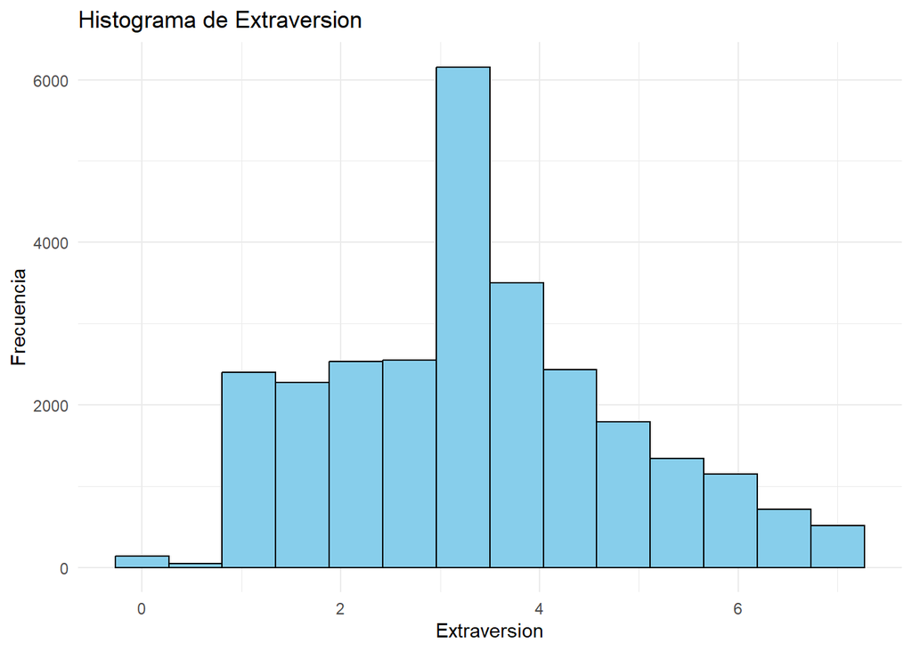

```r
# Definir colores para cada variable de personalidad
color_extraversion <- "skyblue"
color_agreeableness <- "lightcoral"
color_conscientiousness <- "lightgreen"
color_emotional_stability <- "gold"
color_openness <- "mediumpurple"

# Crear histograma y boxplot para la variable de Extraversion
ggplot(df_filtrado, aes(x = Extraversion)) +
  geom_histogram(fill = color_extraversion, color = "black", bins = 14) +
  labs(title = "Histograma de Extraversion",
       x = "Extraversion",
       y = "Frecuencia") +
  theme_minimal()
```

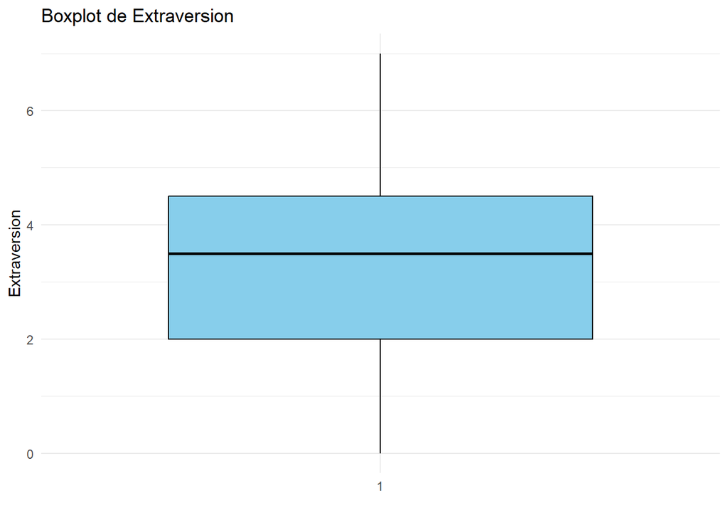

```r
ggplot(df_filtrado, aes(x = factor(1), y = Extraversion)) +
  geom_boxplot(fill = color_extraversion, color = "black") +
  labs(title = "Boxplot de Extraversion",
       x = "",
       y = "Extraversion") +
  theme_minimal()
```

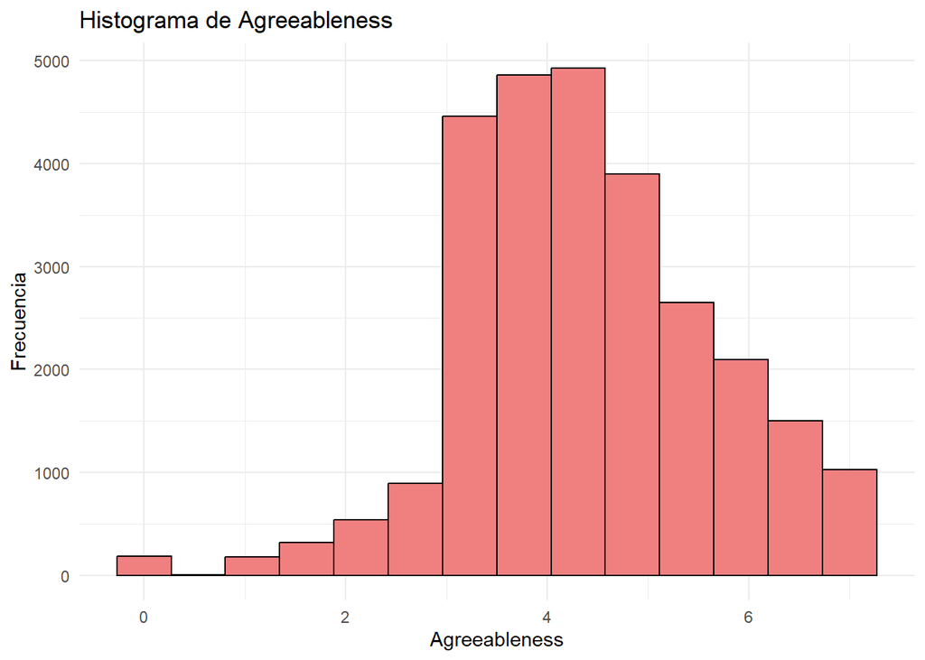

```r
# Crear histograma y boxplot para la variable de Agreeableness
ggplot(df_filtrado, aes(x = Agreeableness)) +
  geom_histogram(fill = color_agreeableness, color = "black", bins = 14) +
  labs(title = "Histograma de Agreeableness",
       x = "Agreeableness",
       y = "Frecuencia") +
  theme_minimal()
```

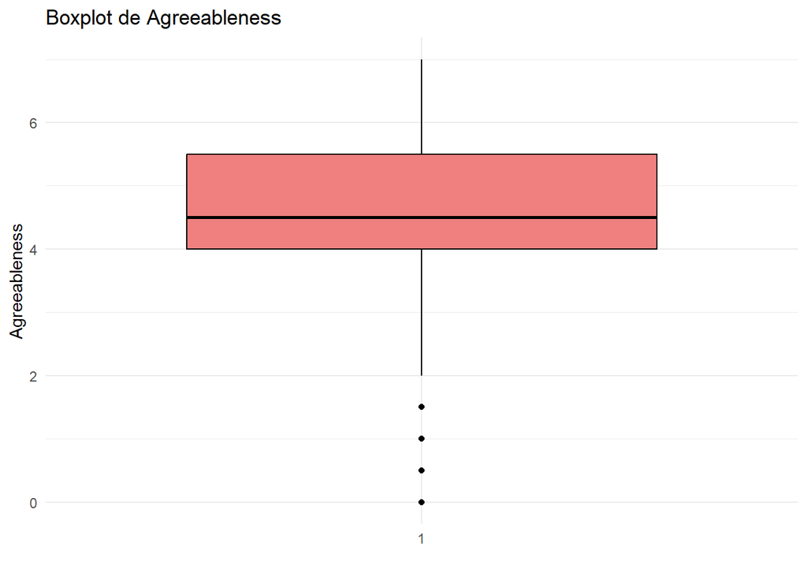

```r
ggplot(df_filtrado, aes(x = factor(1), y = Agreeableness)) +
  geom_boxplot(fill = color_agreeableness, color = "black") +
  labs(title = "Boxplot de Agreeableness",
       x = "",
       y = "Agreeableness") +
  theme_minimal()
```

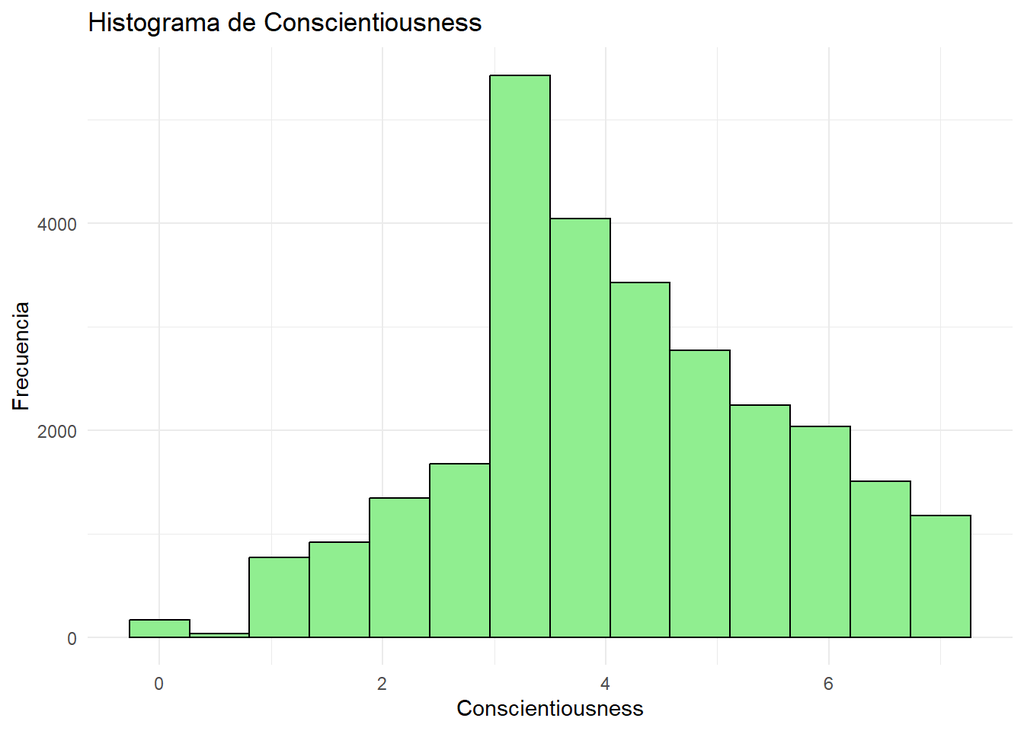

```r
# Crear histograma y boxplot para la variable de Conscientiousness
ggplot(df_filtrado, aes(x = Conscientiousness)) +
  geom_histogram(fill = color_conscientiousness, color = "black", bins = 14) +
  labs(title = "Histograma de Conscientiousness",
       x = "Conscientiousness",
       y = "Frecuencia") +
  theme_minimal()
```

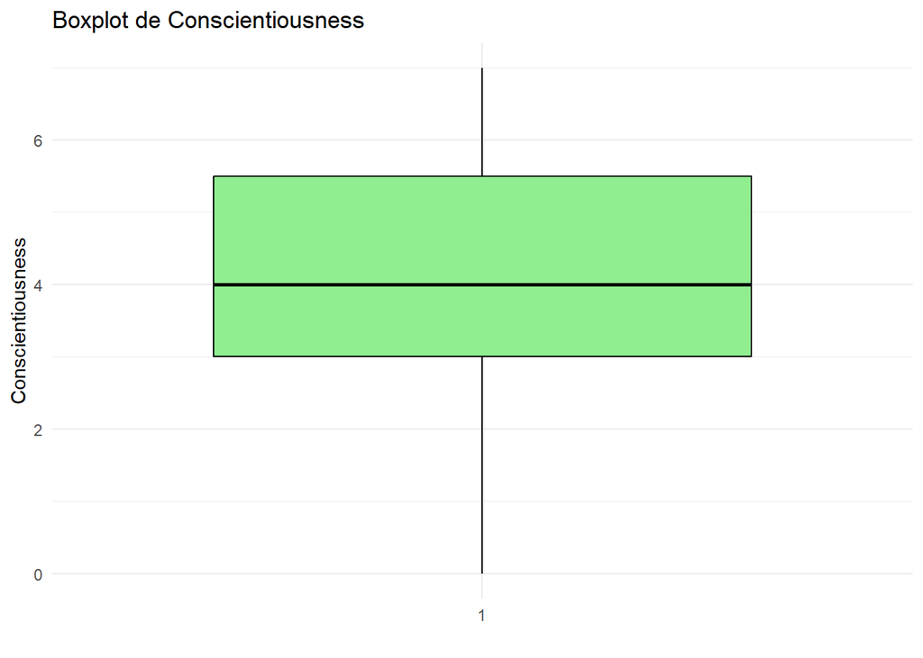

```r
ggplot(df_filtrado, aes(x = factor(1), y = Conscientiousness)) +
  geom_boxplot(fill = color_conscientiousness, color = "black") +
  labs(title = "Boxplot de Conscientiousness",
       x = "",
       y = "Conscientiousness") +
  theme_minimal()
```

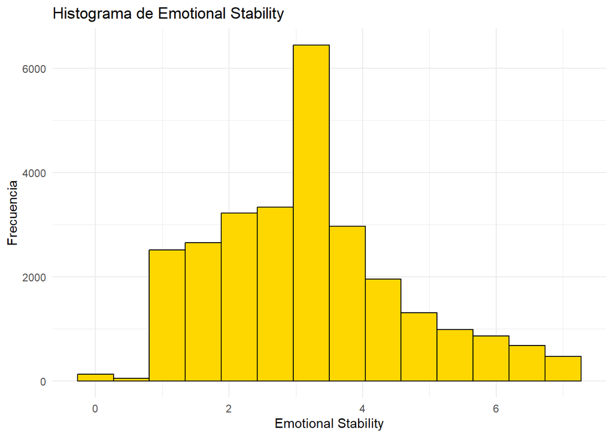

```r
# Crear histograma y boxplot para la variable de Emotional Stability
ggplot(df_filtrado, aes(x = EmotionalStability)) +
  geom_histogram(fill = color_emotional_stability, color = "black", bins = 14) +
  labs(title = "Histograma de Emotional Stability",
       x = "Emotional Stability",
       y = "Frecuencia") +
  theme_minimal()
```

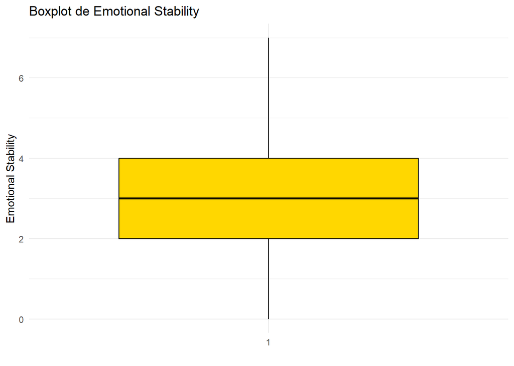

```r
ggplot(df_filtrado, aes(x = factor(1), y = EmotionalStability)) +
  geom_boxplot(fill = color_emotional_stability, color = "black") +
  labs(title = "Boxplot de Emotional Stability",
       x = "",
       y = "Emotional Stability") +
  theme_minimal()
```

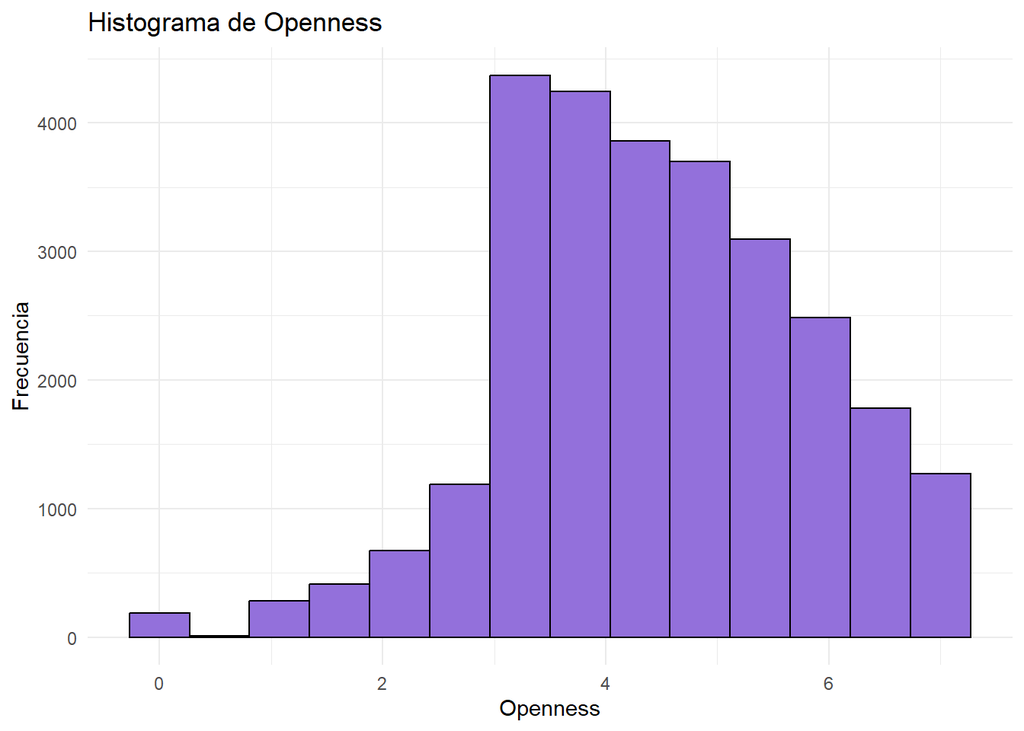

```r
# Crear histograma y boxplot para la variable de Openness
ggplot(df_filtrado, aes(x = Openness)) +
  geom_histogram(fill = color_openness, color = "black", bins = 14) +
  labs(title = "Histograma de Openness",
       x = "Openness",
       y = "Frecuencia") +
  theme_minimal()
```

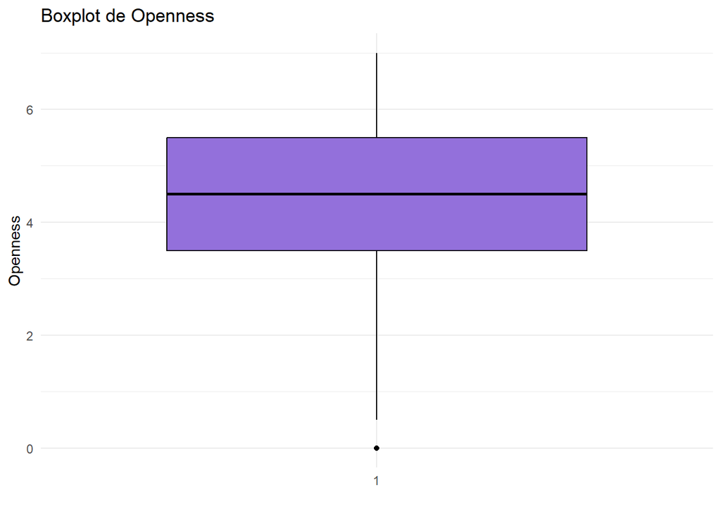

```r
ggplot(df_filtrado, aes(x = factor(1), y = Openness)) +
  geom_boxplot(fill = color_openness, color = "black") +
  labs(title = "Boxplot de Openness",
       x = "",
       y = "Openness") +
  theme_minimal()
```

### Correlaciones

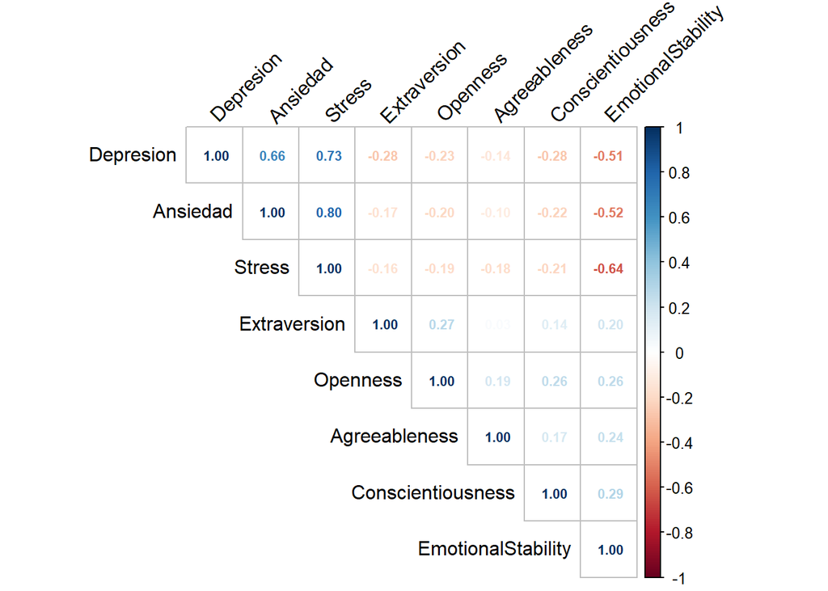

```r
library(corrplot)
# Seleccionar las variables de interés
variables_interes <- c("Depresion", "Ansiedad", "Stress", "Extraversion", "Agreeableness", "Conscientiousness", "EmotionalStability", "Openness")

# Crear una submatriz con las variables seleccionadas
matriz_correlacion <- df_filtrado[, variables_interes]

# Eliminar filas y columnas con valores NA
matriz_correlacion <- matriz_correlacion[complete.cases(matriz_correlacion), ]

# Calcular la matriz de correlación
matriz_correlacion <- cor(matriz_correlacion)

# Visualizar la matriz de correlación usando corrplot
corrplot(matriz_correlacion, method = "number", type = "upper", order = "hclust", tl.col = "black", tl.srt = 45, addCoef.col = "black", number.cex = 0.7)
```

Se observa que la estabilidad emocional tiene una correlacion negativa bastante alta con nuestras tres variables target, mayormente con Estrés. El resto de los rasgos de personalidad tienen todos correlacion negativa pero relativamente baja con nuestras variables target. Analicemos ahora en función de datos personales.

## Modelo CART

### Preparación adicional de datos

Vamos a factorizar columnas que usaremos más adelante, que corresponden a las preguntas de índole personal y demográfica.

```r
columnas_personales <- c("education", "urban", "gender", "engnat", "hand", "religion", "orientation", "race", "voted", "married", "familysize")

# Filtrar filas con valores NA en las columnas de interés
df_filtrado <- df_filtrado[complete.cases(df_filtrado[columnas_personales]), ]

# Identificar y factorizar solo las columnas de tipo "character" o "factor"
df_filtrado[columnas_personales] <- sapply(df_filtrado[columnas_personales], function(x) {
  if(is.character(x) || is.factor(x)) {
    return(as.factor(x))
  } else {
    return(x)
  }
})

# Verificar el resultado
str(df_filtrado[columnas_personales])
```

```
## 'data.frame':    27539 obs. of  11 variables:
##  $ education  : int  2 2 2 1 3 2 1 1 3 4 ...
##  $ urban      : int  3 3 3 3 2 3 1 2 0 2 ...
##  $ gender     : int  2 2 2 2 2 2 2 1 2 1 ...
##  $ engnat     : int  2 1 2 1 2 2 2 1 1 2 ...
##  $ hand       : int  1 2 1 2 3 1 1 1 1 1 ...
##  $ religion   : int  12 7 4 4 10 4 2 6 1 12 ...
##  $ orientation: int  1 0 3 5 1 1 2 1 1 1 ...
##  $ race       : int  10 70 60 70 10 70 60 60 60 60 ...
##  $ voted      : int  2 2 1 2 2 2 2 2 2 2 ...
##  $ married    : int  1 1 1 1 1 1 1 1 1 1 ...
##  $ familysize : int  2 4 3 5 4 4 3 1 2 5 ...
```

### Preparamos nuestro train y test.

Vamos a comenzar factorizando nuestras variables categóricas Depresion_cat, Ansiedad_cat, y Stress_cat

```r
library(dplyr)
library(forcats)

# Columnas a codificar
columnas_a_codificar <- c("Depresion_cat", "Ansiedad_cat", "Stress_cat")

# Función para codificar las categorías
codificar_categoria <- function(x) {
  recode(x,
    "Normal" = 0,
    "Leve" = 1,
    "Moderado" = 2,
    "Severo" = 3,
    .default = as.numeric(as.character(x))
  )
}

# Aplica la codificación a cada columna y crea nuevas columnas
df_filtrado <- df_filtrado %>%
  mutate(
    Depresion_cat_f = codificar_categoria(Depresion_cat),
    Ansiedad_cat_f = codificar_categoria(Ansiedad_cat),
    Stress_cat_f = codificar_categoria(Stress_cat)
  )
```

Verificamos las proporciones de la severidad para Depresión.

```r
prop_target <- prop.table(table(df_filtrado$Depresion_cat))
prop_target
```

```
##
##      Leve  Moderado    Normal    Severo
## 0.0939395 0.1792730 0.2213225 0.5054650
```

```r
library(caret)
set.seed(17)
# Agregar una columna de ID
df_filtrado$ID <- seq_len(nrow(df_filtrado))

# Definir las variables predictoras
variables_predictoras <- c("Extraversion", "Agreeableness", "Conscientiousness", "EmotionalStability", "Openness", "education", "urban", "gender", "engnat", "hand", "religion", "orientation", "race", "voted", "married", "familysize")

# Definir las variables objetivo
variables_objetivo <- c("Depresion_cat", "Ansiedad_cat", "Stress_cat")
df_modelo <- df_filtrado[, c(variables_predictoras, variables_objetivo, "ID")]

# Dividir en train y test
indice_entrenamiento <- createDataPartition(df_modelo$Depresion, p = 0.7, list = FALSE)

#Train
df_entrenamiento <- df_modelo[indice_entrenamiento, ]

#Test
df_prueba <- df_modelo[-indice_entrenamiento, ]
```

### Modelo para Depresion

```r
library(rpart.plot)
# Crear una fórmula para el modelo


variables_predictoras_depresion <- c("Extraversion", "Agreeableness", "Conscientiousness", "EmotionalStability", "Openness",  "Depresion_cat")

variables_predictoras_ansiedad <- c("Extraversion", "Agreeableness", "Conscientiousness", "EmotionalStability", "Openness", "Ansiedad_cat")

variables_predictoras_stress <- c("Extraversion", "Agreeableness", "Conscientiousness", "EmotionalStability", "Openness", "Stress_cat")


df_entrenamiento_depresion <- df_entrenamiento[variables_predictoras_depresion]

df_entrenamiento_stress <- df_entrenamiento[variables_predictoras_stress]

df_entrenamiento_ansiedad <- df_entrenamiento[variables_predictoras_ansiedad]

#formula <- as.formula(paste('Depresion', " ~ ."))

# Entrenar el modelo en el conjunto de entrenamiento
modelo_cart_depresion <- rpart(formula = Depresion_cat ~. , data = df_entrenamiento_depresion, method = 'class')

# Resumen del modelo
print(paste("Resumen del modelo para", 'Depresion'))
```

```
## [1] "Resumen del modelo para Depresion"
```

```r
print(summary(modelo_cart_depresion))
```

```
## Call:
## rpart(formula = Depresion_cat ~ ., data = df_entrenamiento_depresion,
##     method = "class")
##   n= 19278
##
##           CP nsplit rel error    xerror        xstd
## 1 0.08023914      0 1.0000000 1.0000000 0.007281152
## 2 0.05821271      1 0.9197609 0.9197609 0.007251863
## 3 0.01000000      2 0.8615481 0.8663730 0.007206681
##
## Variable importance
## EmotionalStability  Conscientiousness      Agreeableness           Openness
##                 79                  8                  5                  5
##       Extraversion
##                  3
##
## Node number 1: 19278 observations,    complexity param=0.08023914
##   predicted class=Severo  expected loss=0.4945534  P(node) =1
##     class counts:  1811  3456  4267  9744
##    probabilities: 0.094 0.179 0.221 0.505
##   left son=2 (8566 obs) right son=3 (10712 obs)
##   Primary splits:
##       EmotionalStability < 3.25 to the right, improve=1101.90400, (0 missing)
##       Conscientiousness  < 4.25 to the right, improve= 343.14590, (0 missing)
##       Extraversion       < 3.25 to the right, improve= 292.54760, (0 missing)
##       Openness           < 4.25 to the right, improve= 228.50220, (0 missing)
##       Agreeableness      < 4.25 to the right, improve=  64.67917, (0 missing)
##   Surrogate splits:
##       Conscientiousness < 4.25 to the right, agree=0.600, adj=0.101, (0 split)
##       Agreeableness     < 5.25 to the right, agree=0.582, adj=0.060, (0 split)
##       Openness          < 5.25 to the right, agree=0.577, adj=0.048, (0 split)
##       Extraversion      < 4.25 to the right, agree=0.568, adj=0.027, (0 split)
##
## Node number 2: 8566 observations,    complexity param=0.05821271
##   predicted class=Normal  expected loss=0.6096194  P(node) =0.4443407
##     class counts:  1093  1550  3344  2579
##    probabilities: 0.128 0.181 0.390 0.301
##   left son=4 (4353 obs) right son=5 (4213 obs)
##   Primary splits:
##       EmotionalStability < 4.25 to the right, improve=221.81220, (0 missing)
```

[output cut: 20 more lines]

```
## Node number 5: 4213 observations
##   predicted class=Severo  expected loss=0.6104913  P(node) =0.2185393
##     class counts:   573   913  1086  1641
##    probabilities: 0.136 0.217 0.258 0.390
##
## n= 19278
##
## node), split, n, loss, yval, (yprob)
##       * denotes terminal node
##
## 1) root 19278 9534 Severo (0.09394128 0.17927171 0.22134039 0.50544662)
##   2) EmotionalStability>=3.25 8566 5222 Normal (0.12759748 0.18094793 0.39038057 0.30107401)
##     4) EmotionalStability>=4.25 4353 2095 Normal (0.11945785 0.14633586 0.51872272 0.21548357) *
##     5) EmotionalStability< 4.25 4213 2572 Severo (0.13600760 0.21671018 0.25777356 0.38950866) *
##   3) EmotionalStability< 3.25 10712 3547 Severo (0.06702763 0.17793129 0.08616505 0.66887603) *
```

```r
# Visualizar el árbol de decisión
rpart.plot(modelo_cart_depresion)
```

[output not shown]

Vemos que, sin pasarle ningún hiperparámetro, el árbol decide únicamente en base al valor que tenga una persona en Estabilidad Emocional, y no logra clasificar Leve ni Moderado

Probemos ahora un segundo modelo agregando algunos hiperparámetros:

```r
# Fit
modelo_cart_depresion_md <- rpart(formula = Depresion_cat ~. , data = df_entrenamiento_depresion, method = "class", control = rpart.control(maxdepth = 10))

#Resumen del modelo
#print(paste("Resumen del modelo para", 'Depresion'))
#print(head(summary(modelo_cart_depresion_md)))

#Imprimimos el arbol
rpart.plot(modelo_cart_depresion_md)
```

[output not shown]

```r
#Fit 2
modelo_cart_depresion_mb <- rpart(formula = Depresion_cat ~. , data = df_entrenamiento_depresion, method = "class", control = rpart.control(minbucket = 2))

#Resumen del modelo
#print(paste("Resumen del modelo para", 'Depresion'))
#print(head(summary(modelo_cart_depresion_mb)))
```

```r
#Imprimimos el arbol
rpart.plot(modelo_cart_depresion_mb)
```

[output not shown]

Vemos que con maxdepth y minbucket el árbol no cambia. Veamos qué pasa si modificamos la complejidad.

#### Variando complejidad

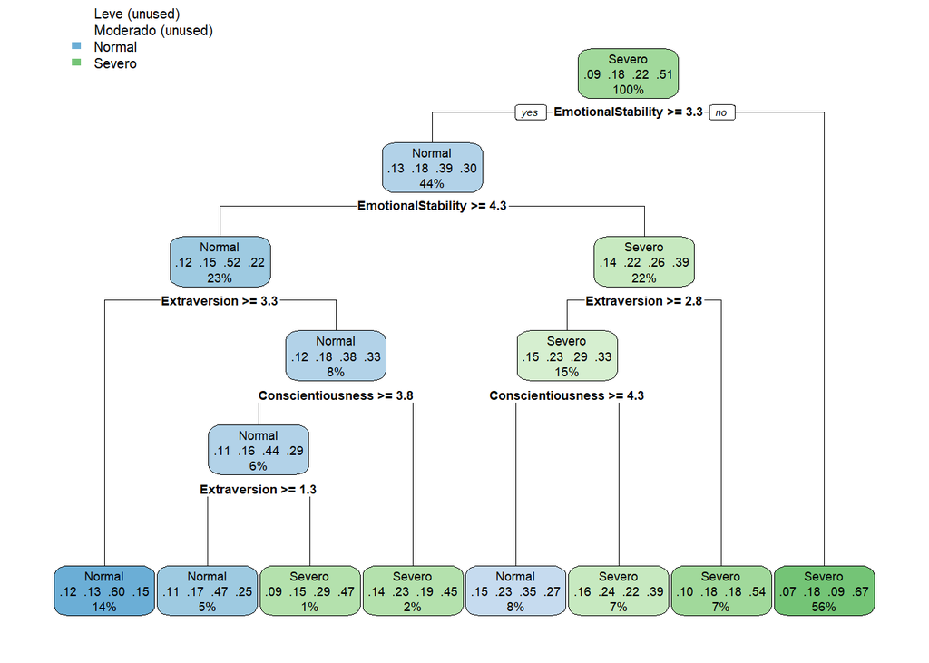

```r
# Fit
modelo_cart_depresion_cp <- rpart(formula = Depresion_cat ~. , data = df_entrenamiento_depresion, method = "class", control = rpart.control(cp = 0.002))

#Resumen del modelo
#print(paste("Resumen del modelo para", 'Depresion'))
#print(head(summary(modelo_cart_depresion_cp)))

#Imprimimos el arbol
rpart.plot(modelo_cart_depresion_cp)
```

Vemos que aunque le dejemos crecer en complejidad, sigue prediciendo únicamente dos de los 4 casos que tenemos, pero comienza a utilizar algunas nuevas categorias para la predicción.

Veamos cuándo aparece nuestra nueva clase en las predicciones.

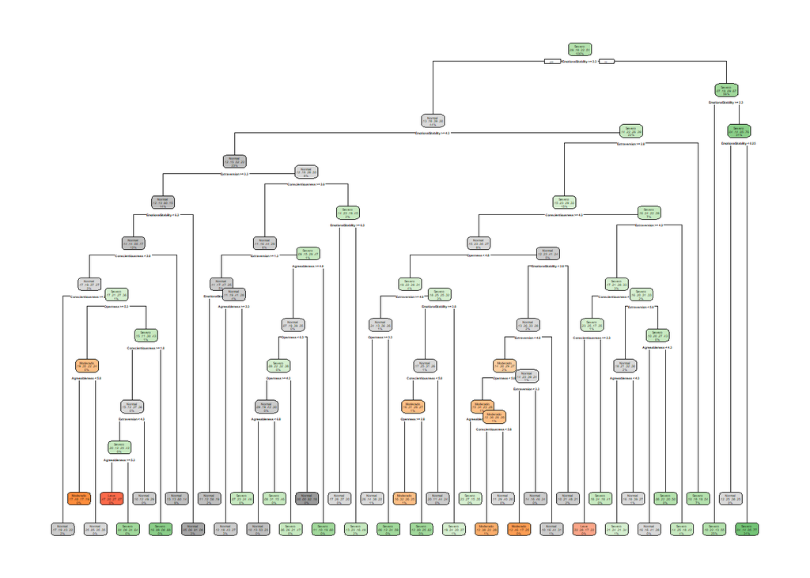

```r
#Fit
modelo_cart_depresion_cp <- rpart(formula = Depresion_cat ~. , data = df_entrenamiento_depresion, method = "class", control = rpart.control(cp = 0.0004))

#Resumen
#print(paste("Resumen del modelo para", 'Depresion'))
#print(head(summary(modelo_cart_depresion_cp)))

#Grafico
rpart.plot(modelo_cart_depresion_cp)
```

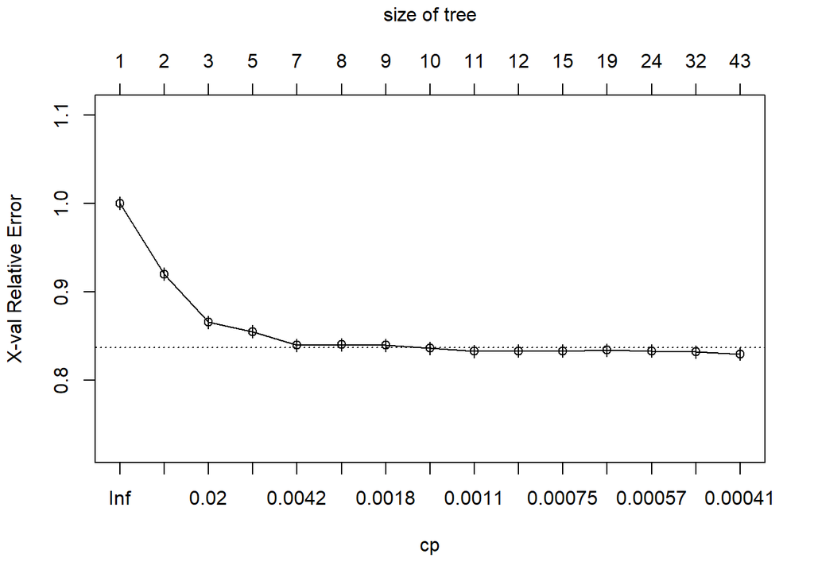

```r
plotcp(modelo_cart_depresion_cp)
```

Aquí vemos que con un cp = 0.0004 aparecen nuevas clases, pero tenemos muchos más nodos terminales y un árbol considerablemente más complejo que el anterior, donde sacrificamos explicabilidad. Si nos fijamos en el error estimado de generalización en base a CP, parecería que a partir de cp=0.0042 los valores de error son muy similares, entonces podemos considerar quedarnos con el árbol más chico de ese rango que sería un árbol de tamaño 7 y cp= 0.0042

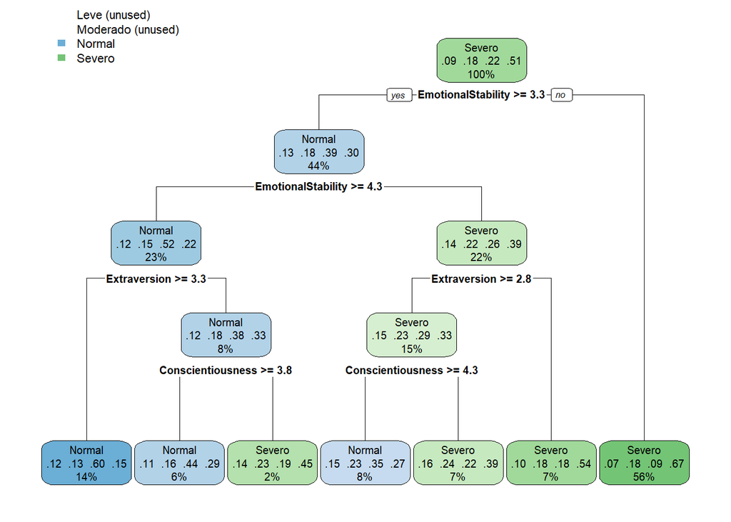

```r
modelo_cart_depresion_cp_min <- rpart(formula = Depresion_cat ~. , data = df_entrenamiento_depresion, method = "class", control = rpart.control(cp = 0.0042))

#Resumen
#print(paste("Resumen del modelo para", 'Depresion'))
#print(head(summary(modelo_cart_depresion_cp)))

#Grafico
rpart.plot(modelo_cart_depresion_cp_min)
```

Veamos entonces qué variables son las más importantes en este modelo.

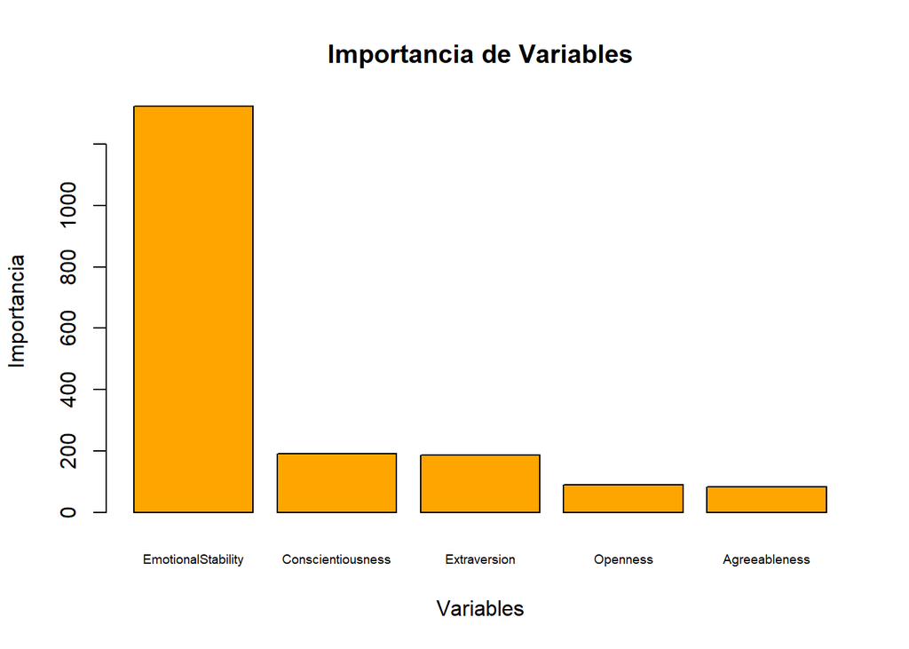

```r
importancia_variables <- data.frame(variable = names(modelo_cart_depresion_cp_min$variable.importance),
                                     importancia = modelo_cart_depresion_cp_min$variable.importance)

#Ordenamos importancia
importancia_variables <- importancia_variables[order(-importancia_variables$importancia), ]

#Grafico de barras
barplot(importancia_variables$importancia, names.arg = importancia_variables$variable,
        col = "orange", main = "Importancia de Variables",
        xlab = "Variables", ylab = "Importancia", cex.names = 0.60)
```

Podemos ver que la variable más importante es EmotionalStability, le sigue Conscientiousness y Extraversion. Esto tiene sentido ya que son las variables que aparecieron primero en los splits del arbol.

¿Qué pasa si agregamos más variables?

#### Modelo con más variables

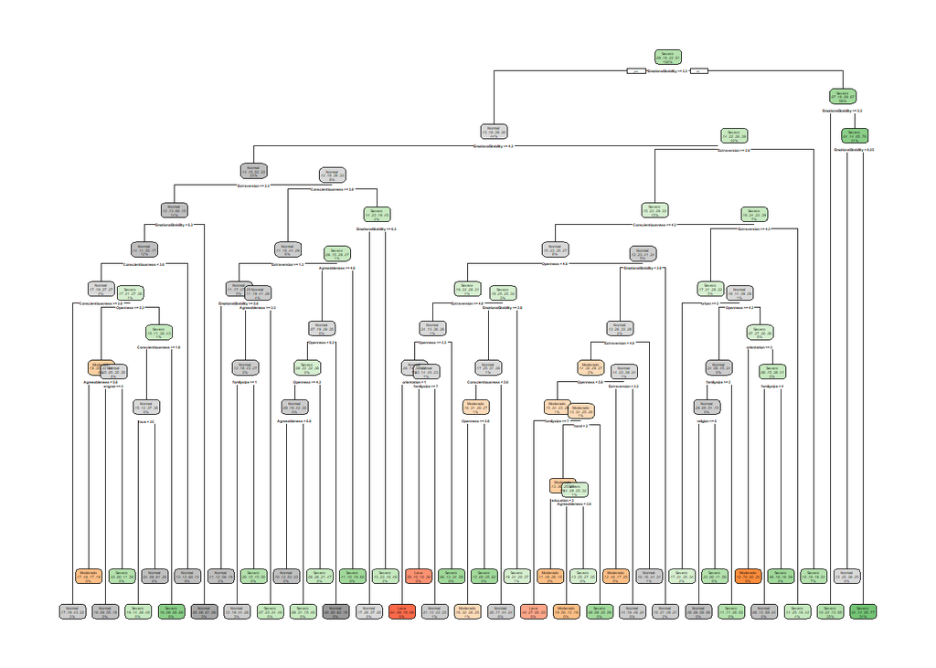

```r
variables_predictoras_mas <- c("Extraversion", "Agreeableness", "Conscientiousness", "EmotionalStability", "Openness", "education", "urban", "gender", "engnat", "hand", "religion", "orientation", "race", "voted", "married", "familysize", "Depresion_cat")


df_entrenamiento_depresion_mas <- df_entrenamiento[variables_predictoras_mas]

#Fit
modelo_cart_depresion_cp_mas <- rpart(formula = Depresion_cat ~. , data = df_entrenamiento_depresion_mas, method = "class", control = rpart.control(cp = 0.00039))

#print(paste("Resumen del modelo para", 'Depresion'))
#print(summary(modelo_cart_depresion_cp_mas))

#Grafico arbol
rpart.plot(modelo_cart_depresion_cp_mas)
```

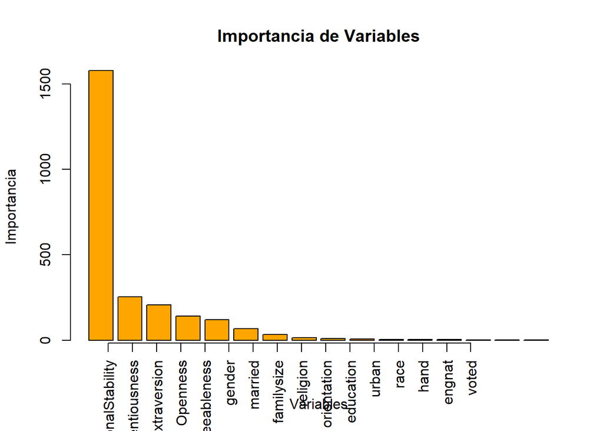

```r
#Importancia
importancia_variables_mas <- data.frame(variable = names(modelo_cart_depresion_cp_mas$variable.importance),
                                     importancia = modelo_cart_depresion_cp_mas$variable.importance)

importancia_variables_mas <- importancia_variables_mas[order(-importancia_variables_mas$importancia), ]

barplot(importancia_variables_mas$importancia,
        col = "orange", main = "Importancia de Variables",
        xlab = "Variables", ylab = "Importancia")

#Acomodamos nombres
axis(1, at = seq_along(importancia_variables_mas$variable),
     labels = importancia_variables_mas$variable, las = 2, cex.names= 0.4)
```

Con esto podemos ver que nuestras variables más importantes siguen siendo las de personalidad, mientras que las variables agregadas tienen muy poca importancia. Podemos verificar en qué grado usa cada variable en los splits.

```r
tabla_variables <- as.data.frame(modelo_cart_depresion_cp_mas$frame$var[modelo_cart_depresion_cp_mas$frame$var != "<leaf>"])
names(tabla_variables) <- c("variable")
tabla_variables %>%
  group_by(variable) %>%
  summarise(n = n()) %>%
  mutate(freq = round(n / sum(n), 2)) %>%
  arrange(-n)
```

```
## # A tibble: 13 × 3
##    variable               n  freq
##    <chr>              <int> <dbl>
##  1 EmotionalStability     9  0.19
##  2 Openness               8  0.17
##  3 Extraversion           7  0.15
##  4 Conscientiousness      6  0.12
##  5 Agreeableness          5  0.1
##  6 familysize             5  0.1
##  7 orientation            2  0.04
##  8 education              1  0.02
##  9 engnat                 1  0.02
## 10 hand                   1  0.02
## 11 race                   1  0.02
## 12 religion               1  0.02
## 13 urban                  1  0.02
```

Efectivamente podemos ver que las variables de personalidad son las más usadas por nuestro modelo para poder predecir, y luego aparecen el tamaño del grupo familiar, la orientación sexual, el nivel educativo alcanzado, entre otras, pero con mucha menos frecuencia.

#### Poda del árbol

Cuando tenemos árboles que son complejos tenemos mayor posibilidad de overfitear. Para esto, podemos realizar poda del árbol, que consiste en eliminar ramas (nodos y hojas) para reducir su complejidad. Para nuestro caso, se eliminan las ramas o sub-árboles que no traen diferencias significativas, es decir que menor reducción de impureza proporcionan.

Si bien la poda puede ser Pre-Pruning o Post-Pruning, en nuestro caso haremos Post-Pruning lo que implica partir de un árbol complejo y luego podarlo.

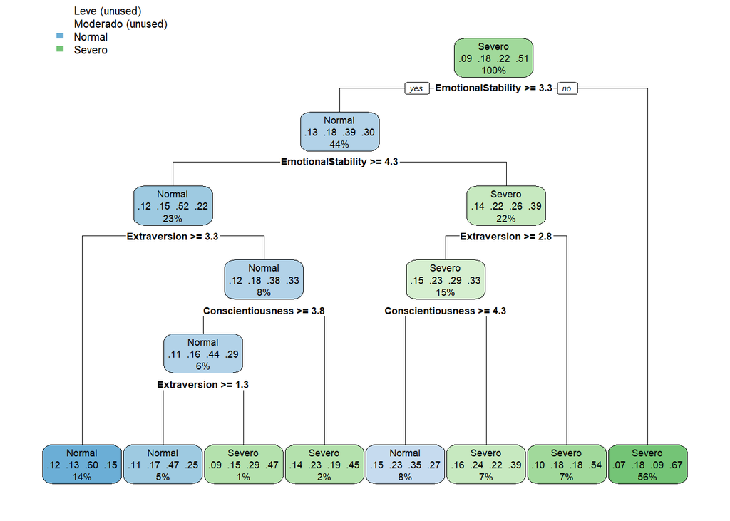

```r
modelo_cart_depresion_cp_mas_pruned <- prune(modelo_cart_depresion_cp_mas, cp = 0.00195)

#print(summary(modelo_cart_depresion_cp_mas_pruned))

rpart.plot(modelo_cart_depresion_cp_mas_pruned)
```

```r
tabla_variables_pruned <- as.data.frame(modelo_cart_depresion_cp_mas_pruned$frame$var[modelo_cart_depresion_cp_mas_pruned$frame$var != "<leaf>"])
names(tabla_variables_pruned) <- c("variable")
tabla_variables %>%
  group_by(variable) %>%
  summarise(n = n()) %>%
  mutate(freq = round(n / sum(n), 2)) %>%
  arrange(-n)
```

```
## # A tibble: 13 × 3
##    variable               n  freq
##    <chr>              <int> <dbl>
##  1 EmotionalStability     9  0.19
##  2 Openness               8  0.17
##  3 Extraversion           7  0.15
##  4 Conscientiousness      6  0.12
##  5 Agreeableness          5  0.1
##  6 familysize             5  0.1
##  7 orientation            2  0.04
##  8 education              1  0.02
##  9 engnat                 1  0.02
## 10 hand                   1  0.02
## 11 race                   1  0.02
## 12 religion               1  0.02
## 13 urban                  1  0.02
```

De esta manera obtenemos un árbol podado a una complejidad 0.00195

### Métricas y comparación con otros modelos

Vamos a generar modelos de Naive Bayes y Regresion Logistica Multinomial

```r
naive_bay <- e1071::naiveBayes(Depresion_cat ~ ., data = df_entrenamiento_depresion_mas)

modelo_rlm <- nnet::multinom(Depresion_cat ~ ., data = df_entrenamiento_depresion_mas)
library(pROC)
#Definimos una funcion para calcular las métriacs

calcular_metricas <- function(modelo, datos_prueba){

  predicciones <- predict(modelo, newdata = datos_prueba, type = "class")
  matriz_confusion <- caret::confusionMatrix(predicciones, datos_prueba$Depresion_cat)$table


  precision <- sum(diag(matriz_confusion)) / sum(matriz_confusion)
  sensibilidad <- matriz_confusion[2,2] / sum(matriz_confusion[2,])
  especificidad <- matriz_confusion[1,1] / sum(matriz_confusion[1,])
  f1_score <- 2* (sensibilidad * precision) / (precision + sensibilidad)

  # Obtener el nombre del modelo
  nombre_modelo <- deparse(substitute(modelo))

  # Imprimir la matriz de confusión con el nombre del modelo
  cat("Matriz de confusión para", nombre_modelo, ":\n")
  print(matriz_confusion)



  resultados <- data.frame(
    Modelo = deparse(substitute(modelo)),
    Precision = precision,
    Sensibilidad = sensibilidad,
    Especificidad = especificidad,
    F1_Score = f1_score
  )
  return(resultados)
}

df_prueba_depresion_mas <- df_prueba[, variables_predictoras_mas]
df_prueba_depresion_mas$Depresion_cat <- as.factor(df_prueba_depresion_mas$Depresion_cat
                                                   )
resultados_cart <- calcular_metricas(modelo_cart_depresion_cp_mas, df_prueba_depresion_mas)
```

```
## Matriz de confusión para modelo_cart_depresion_cp_mas :
##           Reference
## Prediction Leve Moderado Normal Severo
##   Leve        1        5      5      3
##   Moderado   21       37     48     31
##   Normal    252      313   1030    396
##   Severo    502     1126    745   3746
```

```r
resultados_nb <- calcular_metricas(naive_bay, df_prueba_depresion_mas)
```

```
## Matriz de confusión para naive_bay :
##           Reference
## Prediction Leve Moderado Normal Severo
##   Leve        0        0      0      0
##   Moderado    7       16     15     26
##   Normal    336      411   1204    563
##   Severo    433     1054    609   3587
```

```r
resultados_rlm <- calcular_metricas(modelo_rlm, df_prueba_depresion_mas)
```

```
## Matriz de confusión para modelo_rlm :
##           Reference
## Prediction Leve Moderado Normal Severo
##   Leve        0        0      0      0
##   Moderado    0        0      0      0
##   Normal    261      313   1087    379
##   Severo    515     1168    741   3797
```

```r
resultados_cart_pruned <- calcular_metricas(modelo_cart_depresion_cp_mas_pruned, df_prueba_depresion_mas)
```

```
## Matriz de confusión para modelo_cart_depresion_cp_mas_pruned :
##           Reference
## Prediction Leve Moderado Normal Severo
##   Leve        0        0      0      0
##   Moderado    0        0      0      0
##   Normal    298      383   1115    462
##   Severo    478     1098    713   3714
```

```r
tabla_resultados <- rbind(resultados_cart, resultados_cart_pruned, resultados_nb, resultados_rlm)
tabla_resultados
```

```
##                                Modelo Precision Sensibilidad Especificidad
## 1        modelo_cart_depresion_cp_mas 0.5827382     0.270073    0.07142857
## 2 modelo_cart_depresion_cp_mas_pruned 0.5845539          NaN           NaN
## 3                           naive_bay 0.5818908     0.250000           NaN
## 4                          modelo_rlm 0.5912117          NaN           NaN
##    F1_Score
## 1 0.3690895
## 2       NaN
## 3 0.3497399
## 4       NaN
```

Con esto podemos ver algunas cosas:

En primer lugar, ningun modelo es bueno en términos prácticos, ya que estamos hablando de una precisión menor al 60%. Además, tenemos 3 modelos que no logran predecir todos los casos. Dos de ellos solo predicen 2 de las clases (Normal y Severo), 1 de ellos predice también sobre Moderado, y solo 1, el árbol sin cortar, logra predecir todas las clases, aunque con poca precision.

### Apéndice: (Modelos Ansiedad y Estrés)

A continuación dejamos la aplicación para modelos de Ansiedad y Estrés. En este caso, vamos a hacerlo directamente con todas las variables (rasgos de personalidad y datos personales)

#### Ansiedad

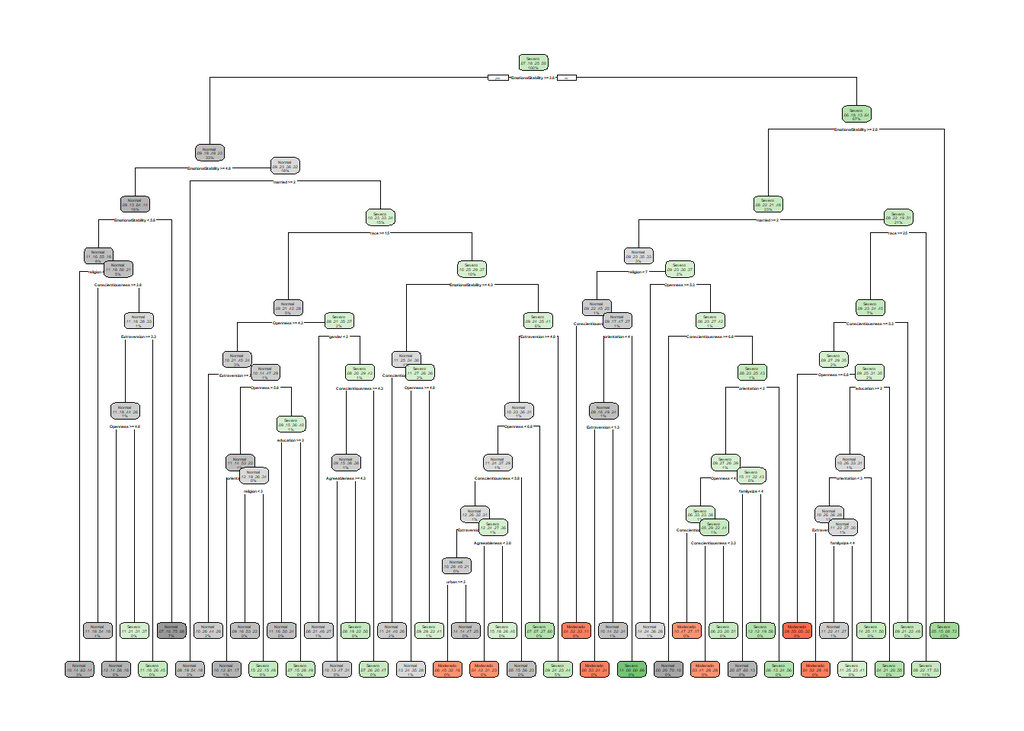

```r
variables_predictoras_ansiedad <- c("Extraversion", "Agreeableness", "Conscientiousness", "EmotionalStability", "Openness", "education", "urban", "gender", "engnat", "hand", "religion", "orientation", "race", "voted", "married", "familysize", "Ansiedad_cat")


df_entrenamiento_ansiedad <- df_entrenamiento[variables_predictoras_ansiedad]

#Fit
modelo_cart_ansiedad <- rpart(formula = Ansiedad_cat ~. , data = df_entrenamiento_ansiedad, method = "class", control = rpart.control(cp = 0.00039))

#print(paste("Resumen del modelo para", 'Depresion'))
#print(summary(modelo_cart_depresion_cp_mas))

#Grafico arbol
rpart.plot(modelo_cart_ansiedad)
```

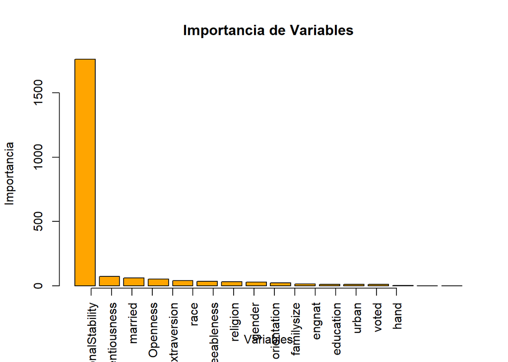

```r
#Importancia
importancia_variables_ansiedad<- data.frame(variable = names(modelo_cart_ansiedad$variable.importance),
                                     importancia = modelo_cart_ansiedad$variable.importance)

importancia_variables_ansiedad <- importancia_variables_ansiedad[order(-importancia_variables_ansiedad$importancia), ]

barplot(importancia_variables_ansiedad$importancia,
        col = "orange", main = "Importancia de Variables",
        xlab = "Variables", ylab = "Importancia")

#Acomodamos nombres
axis(1, at = seq_along(importancia_variables_ansiedad$variable),
     labels = importancia_variables_ansiedad$variable, las = 2, cex.names= 0.4)
```

En principio armamos un árbol saturado para luego podarlo. Pero es interesante que entre las variables importantes, si bien Estabilidad Emocional sigue siendo definitivamente la más importante, aparece la variable de Married en tercer lugar por encima de otros tres rasgos de personalidad.

```r
tabla_variables_ansiedad <- as.data.frame(modelo_cart_ansiedad$frame$var[modelo_cart_ansiedad$frame$var != "<leaf>"])
names(tabla_variables_ansiedad) <- c("variable")
tabla_variables_ansiedad %>%
  group_by(variable) %>%
  summarise(n = n()) %>%
  mutate(freq = round(n / sum(n), 2)) %>%
  arrange(-n)
```

```
## # A tibble: 13 × 3
##    variable               n  freq
##    <chr>              <int> <dbl>
##  1 Conscientiousness      9  0.19
##  2 Openness               8  0.17
##  3 Extraversion           6  0.13
##  4 EmotionalStability     5  0.11
##  5 orientation            4  0.09
##  6 religion               3  0.06
##  7 Agreeableness          2  0.04
##  8 education              2  0.04
##  9 familysize             2  0.04
## 10 married                2  0.04
## 11 race                   2  0.04
## 12 gender                 1  0.02
## 13 urban                  1  0.02
```

Sin embargo, Married no parece ser una columna tan usada por el modelo, y nuevamente tenemos 4 de los 5 rasgos de personalidad en los primeros lugares.